# CS 422

### Part 2.2. a)

```r
df_s1 <- read.csv("s1.csv",header = TRUE, sep = "," )
print(paste0("The mean for x is: ", round(mean(df_s1$x), 2)))
```

```
[1] "The mean for x is: 514937.56"
```

```r
print(paste0("The mean for y is: ", round(mean(df_s1$y), 2)))
```

```
[1] "The mean for y is: 494709.29"
```

```r
print(paste0("The std for x is: ", round(sd(df_s1$x), 2)))
```

```
[1] "The std for x is: 244465.9"
```

```r
print(paste0("The std for y is: ", round(sd(df_s1$y), 2)))
```

```
[1] "The std for y is: 235840.85"
```

Taking into account the results of the x and y labels mean and standard deviation, it can be concluded that the data could be treated for clustering without being standardized due to the fact that both, the mean and the deviation are of the same order. Nevertheless, it is a good practice to standardize the data in order to avoid differences in labels numerical values order, influencing the results when computing Manhattan distances for example.

### Part 2.2.b)

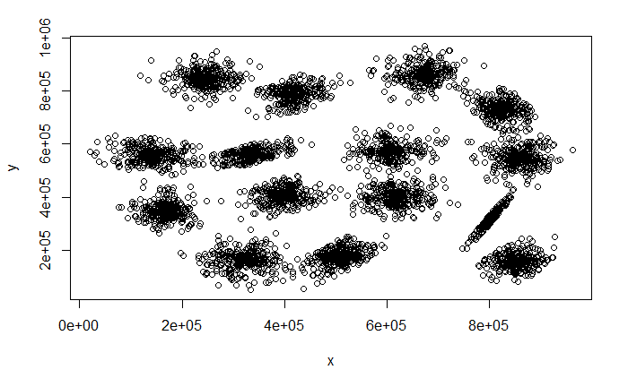

```r
plot(df_s1)
```

```r
NA
NA
```

15 different clusters can be easily seen. In a general overview, it could be said that the clusters are fairly clearly separated, even though there are some popints that are really close to other clusters.

### Part 2.2.c)

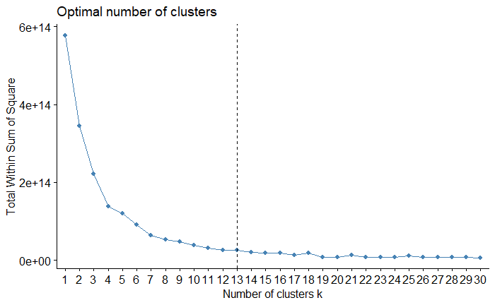

```r
n2 <- fviz_nbclust(df_s1, kmeans, method = "wss", k.max = 30) +
geom_vline(xintercept = 13, linetype = 2)

print(n2)
```

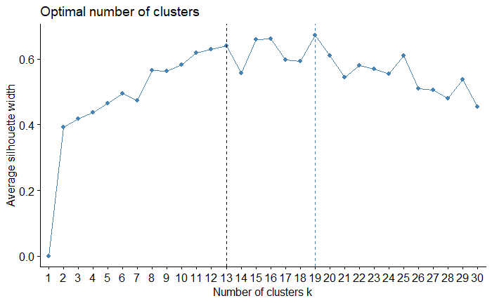

```r
n3 <- fviz_nbclust(df_s1, kmeans, method = "silhouette", k.max = 30) +
geom_vline(xintercept = 13, linetype = 2)
```

```r
NA
NA
```

When it comes to choose a number of clusters for the algorithm, it must be taken into account the general rule of minimizing the SSE error. Therefore, the largest number of clusters would be chosen due to the fact that the sSE function seems to be monotically decreasing for the number of clusters. But it must also be taken into account the pace at which the SSE residuals decrease. Therefore, any number close to 13 clusters would de a good option in terms of minimal SSE because the SSE minimal value starts to converge, and also taking into account that close to the 12 and 14 clusters zone, there is a small discontinuity in the “Average silhouette width”.

In order to be more accurate, a 19 clusters option would also be a really good fit. But its SSE value would be almost the same as for the 13 clusters case. Nevertheless, in the silhouette graph it can be seen that the 19 clusters clustering would have a higher value of “Average silhouette width”.

### Part 2.2.d)

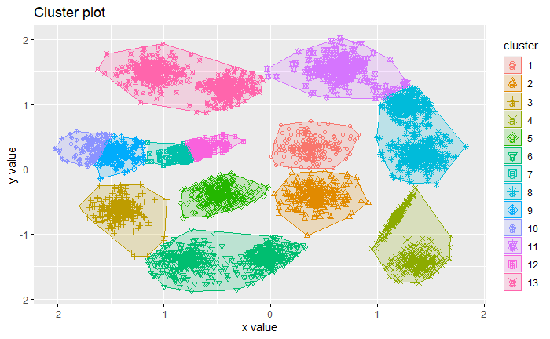

```r
kopt2 <- kmeans(df_s1, centers=13)
fviz_cluster(kopt2, df_s1, repel = TRUE)
```

The clustering algorithm did a really good job, but it can be seen that same clusters encompassed more than one group. Therefore, let’s check the 19 clusters solution.

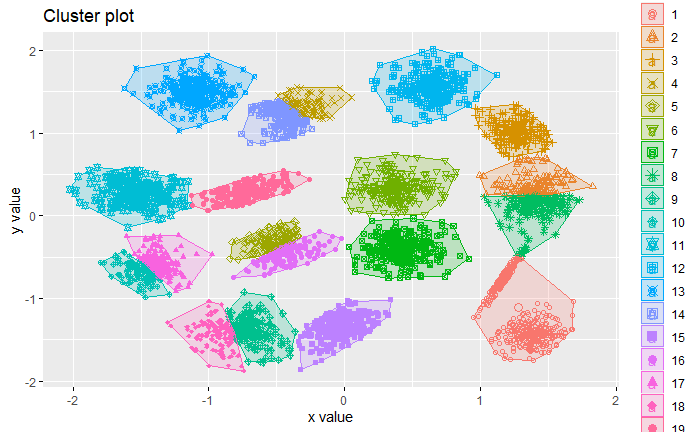

```r
kopt2 <- kmeans(df_s1, centers=19)
fviz_cluster(kopt2, df_s1, repel = TRUE)
```

With 19 clusters it seems to be a better or at least more accurate results. But now, it happens otherwise, the same group is clustered by more than one cluster sometimes as it can be seen in the light green and orange cluster.

### Part 2.2.e)

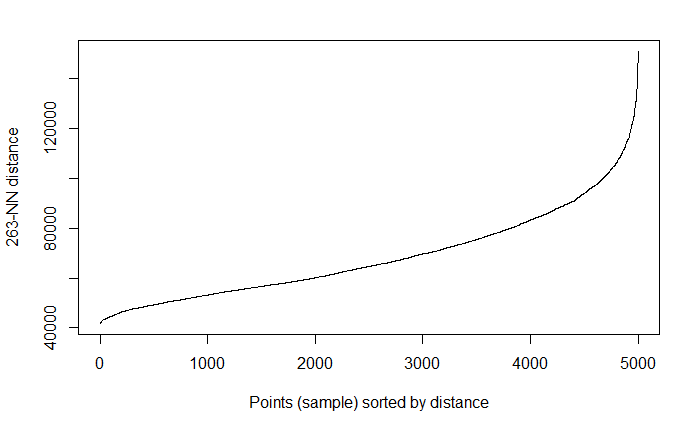

```r
knn <- kNNdistplot(df_s1, 263, all = FALSE)
```

```r
NA
NA
```

```r
minpts <- 263
dbs <- dbscan(df_s1, 60000, MinPts = minpts)
print("\n")
```

```
[1] "\n"
```

```r
print("\n")
```

```
[1] "\n"
```

```r
print("\n")
```

```
[1] "\n"
```

```r
print(paste0("With ", minpts , " MinPts and ", dbs$eps ," eps, ", range(dbs$cluster)[2], " clusters were obtained."))
```

[output not shown]